# Orbital Angular Momentum in Quantum Mechanics

Author

Daniel Fischer

# Orbital angular momentum: overview and plan

To solve the Schrödinger equation for the hydrogen atom, we must understand the angular part of the wave function. This leads naturally to the quantum-mechanical theory of **orbital angular momentum** and to the spherical harmonics $Y_\ell^m(\theta,\varphi)$.

A more general discussion of angular momentum—including the abstract angular-momentum algebra, ladder operators, spin, and the coupling of different angular momenta—is given in Angular Momenta and Their Couplings.

Some of those general results are repeated here so that the derivation of the hydrogen wave function can be followed without requiring that chapter as a prerequisite.

The specific goals for this chapter are:

1. Derive the quantum-mechanical operator for orbital angular momentum, $\hat{\vec L}$, and analyze its key commutation relations.
2. Employ separation of variables in spherical coordinates to transform the angular eigenvalue problem into ordinary differential equations.
3. Solve these equations to determine the allowed eigenvalues of $\hat L^2$ and $\hat L_z$ and the corresponding eigenfunctions.
4. Introduce the spherical harmonics $Y_\ell^m(\theta,\varphi)$ as the angular part of the hydrogen wave function.

# 1. Angular Momentum in Cartesian Coordinates

In **classical mechanics**, the angular momentum is defined as the cross product
$$\vec L = \vec r \times \vec p,$$
with
$$\vec r =
\begin{pmatrix}
x \\ y \\ z
\end{pmatrix},
\quad
\vec p =
\begin{pmatrix}
p_x \\ p_y \\ p_z
\end{pmatrix}.$$

The cross product gives
$$\vec L =
\begin{pmatrix}
L_x \\ L_y \\ L_z
\end{pmatrix}
=
\begin{pmatrix}
y p_z - z p_y \\
z p_x - x p_z \\
x p_y - y p_x
\end{pmatrix}.$$

In **quantum mechanics**, we replace position and momentum by operators:

$$\hat{\vec r} =
\begin{pmatrix}
\hat x \\ \hat y \\ \hat z
\end{pmatrix},
\qquad
\hat{\vec p} =
\begin{pmatrix}
\hat p_x \\ \hat p_y \\ \hat p_z
\end{pmatrix},
\qquad
\hat{\vec L} = \hat{\vec r} \times \hat{\vec p}.$$

In the coordinate representation (position basis), we have

$$\hat{\vec r} =
\begin{pmatrix}
x \\ y \\ z
\end{pmatrix},
\qquad
\hat{\vec p} =
-i\hbar
\begin{pmatrix}
\frac{\partial}{\partial x} \\
\frac{\partial}{\partial y} \\
\frac{\partial}{\partial z}
\end{pmatrix}.$$

Therefore, the angular momentum operator is

$$\hat{\vec L} =
\begin{pmatrix}
\hat L_x \\ \hat L_y \\ \hat L_z
\end{pmatrix}
=
-i\hbar
\begin{pmatrix}
y\frac{\partial}{\partial z} - z\frac{\partial}{\partial y} \\
z\frac{\partial}{\partial x} - x\frac{\partial}{\partial z} \\
x\frac{\partial}{\partial y} - y\frac{\partial}{\partial x}
\end{pmatrix}.$$

## 1.1 Commutation Relations

The following commutation relations are a particular realization of the **general angular-momentum algebra** discussed in Angular Momenta and Their Couplings. Here we derive them directly from $\hat{\vec L}=\hat{\vec r}\times\hat{\vec p}$ so that the orbital-angular-momentum discussion remains self-contained.

From the canonical commutation relations
$$[\hat x_i, \hat p_j] = i\hbar \,\delta_{ij},
\quad
[\hat x_i, \hat x_j] = 0,
\quad
[\hat p_i, \hat p_j] = 0,$$
one can compute
$$[\hat L_x, \hat L_y] = i\hbar \hat L_z, \qquad
[\hat L_y, \hat L_z] = i\hbar \hat L_x, \qquad
[\hat L_z, \hat L_x] = i\hbar \hat L_y.$$

**NoteProof**

The angular momentum components are
$$\hat L_x = \hat y \hat p_z - \hat z \hat p_y, \qquad
\hat L_y = \hat z \hat p_x - \hat x \hat p_z, \qquad
\hat L_z = \hat x \hat p_y - \hat y \hat p_x.$$

Compute the commutator:
$$\begin{aligned}
{[\hat L_x, \hat L_y]} &= [\hat y \hat p_z - \hat z \hat p_y, \; \hat z \hat p_x - \hat x \hat p_z] \\
&= [\hat y \hat p_z, \hat z \hat p_x]
- [\hat y \hat p_z, \hat x \hat p_z]
- [\hat z \hat p_y, \hat z \hat p_x]
+ [\hat z \hat p_y, \hat x \hat p_z].
\end{aligned}$$

Expanding and using the canonical commutators $[\hat x_i, \hat p_j] = i\hbar \delta_{ij}$ and $[\hat x_i, \hat x_j] = [\hat p_i, \hat p_j] = 0$:

1. $[\hat y \hat p_z, \hat z \hat p_x] = \hat y [\hat p_z, \hat z] \hat p_x = -i\hbar \hat y \hat p_x$
2. $-[\hat y \hat p_z, \hat x \hat p_z] = 0$
3. $-[\hat z \hat p_y, \hat z \hat p_x] = 0$
4. $[\hat z \hat p_y, \hat x \hat p_z] = \hat x [\hat z, \hat p_z] \hat p_y = i\hbar \hat x \hat p_y$

Adding the nonzero terms gives
$$[\hat L_x, \hat L_y] = i\hbar (\hat x \hat p_y - \hat y \hat p_x) = i\hbar \hat L_z.$$

Thus the commutator is verified. The remaining commutators, $[\hat L_y, \hat L_z]$ and $[\hat L_z, \hat L_x]$, can be derived using the same method.

These relations show:

**Caution**

- The three components $\hat L_x, \hat L_y, \hat L_z$ **do not commute**.
- Therefore, they cannot in general have simultaneously sharp values, and there is no complete basis of simultaneous eigenstates of all three components.

## 1.2 Total Angular Momentum

The squared operator is defined as
$$\hat L^2 = \hat L_x^2 + \hat L_y^2 + \hat L_z^2.$$

It satisfies
$$[\hat L^2, \hat L_x] = [\hat L^2, \hat L_y] = [\hat L^2, \hat L_z] = 0.$$

Hence, we can find simultaneous eigenstates of $\hat L^2$ and one component, usually chosen to be $\hat L_z$.

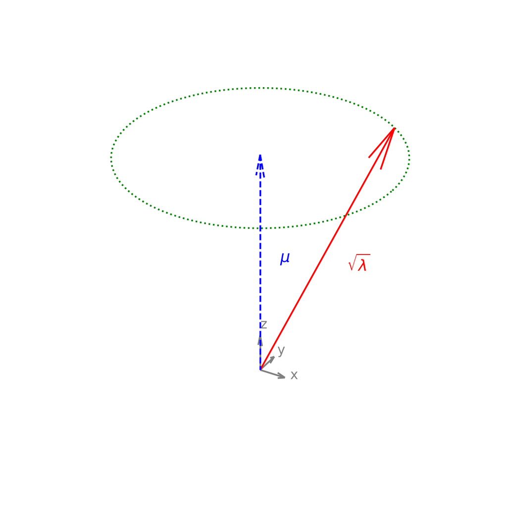

Figure 1: Angular momentum eigenvector in quantum mechanics.

```python
import matplotlib.pyplot as plt
import numpy as np

# Create a new figure and a 3D axis
fig = plt.figure(figsize=(10, 8))
ax = fig.add_subplot(111, projection='3d')

# Set the aspect ratio to 'equal' for better visualization
ax.set_box_aspect([1,1,1])

# Define the components of the angular momentum vector L
Lx = 3
Ly = 4
Lz = 6

# The origin of the vectors
origin = [0, 0, 0]

# Plot the angular momentum vector L
ax.quiver(*origin, Lx, Ly, Lz, color='red', label=r'$\vec{L}$', arrow_length_ratio=0.15)

# Plot the z-component vector Lz
ax.quiver(*origin, 0, 0, Lz, color='blue', linestyle='--', arrow_length_ratio=0.1)

# Plot the x, y, and z unit vectors
ax.quiver(*origin, 1, 0, 0, color='gray', arrow_length_ratio=0.3)
ax.quiver(*origin, 0, 1, 0, color='gray', arrow_length_ratio=0.3)
ax.quiver(*origin, 0, 0, 1, color='gray', arrow_length_ratio=0.3)

# Add labels for the unit vectors
ax.text(1.2, 0, 0, 'x', color='gray', fontsize=12)
ax.text(0, 1.2, 0, 'y', color='gray', fontsize=12)
ax.text(0, 0, 1.2, 'z', color='gray', fontsize=12)

# Set title
# ax.set_title('Quantum Mechanical Angular Momentum Vector', fontsize=16)

# Plot the circle of possible endpoints for the L vector
radius = np.sqrt(Lx**2 + Ly**2)
theta = np.linspace(0, 2 * np.pi, 100)
x_circle = radius * np.cos(theta)
y_circle = radius * np.sin(theta)
z_circle = np.full_like(theta, Lz)
ax.plot(x_circle, y_circle, z_circle, color='green', linestyle=':', label='Uncertainty Circle')

# Add annotations for vector lengths, adjusted for better visibility
lambda_val = Lx**2 + Ly**2 + Lz**2
mu_val = Lz
ax.text(Lx * 0.7, Ly * 0.6, Lz * 0.4, r'$\sqrt{\lambda}$', color='red', fontsize=14, horizontalalignment='left')
ax.text(0.5, 0.5, Lz * 0.5, r'$\mu$', color='blue', fontsize=14, horizontalalignment='left')

# Set the plot limits
ax.set_xlim([-5, 5])
ax.set_ylim([-5, 5])
ax.set_zlim([0, 7])

# Remove background planes and main axes lines, but keep the specific unit vectors
ax.set_axis_off()

# Remove grid
ax.grid(False)

# Save the plot
#plt.savefig('angular_momentum_final.png')

plt.show()
```

# 2. Angular Momentum Operators in Spherical Coordinates

The angular momentum operators in position representation act on wavefunctions $\psi(r,\theta,\varphi)$, where $(r,\theta,\varphi)$ are spherical coordinates:

$$x = r\sin\theta\cos\varphi, \quad
y = r\sin\theta\sin\varphi, \quad
z = r\cos\theta$$

The derivatives transform as:

$$\frac{\partial}{\partial x}, \frac{\partial}{\partial y}, \frac{\partial}{\partial z} \quad \rightarrow \quad \frac{\partial}{\partial r}, \frac{\partial}{\partial \theta}, \frac{\partial}{\partial \varphi}$$

After some algebra (using the chain rule), the z-component simplifies nicely to:

$$\hat{L}_z = -i\hbar \frac{\partial}{\partial \varphi}.$$

The squared angular momentum operator also transforms to spherical coordinates. Using the spherical Laplacian $\nabla^2$ and the fact that $\hat{L}^2$ acts only on angular variables:

$$\hat{L}^2 = -\hbar^2 \left[ \frac{1}{\sin\theta}\frac{\partial}{\partial\theta}\!\Big(\sin\theta\frac{\partial}{\partial\theta}\Big)
+ \frac{1}{\sin^2\theta}\frac{\partial^2}{\partial\varphi^2} \right].$$

We seek functions $Y(\theta,\varphi)$ that are simultaneous eigenfunctions:

$$\hat{L}^2 Y(\theta,\varphi) = \lambda\, Y(\theta,\varphi), \qquad
\hat{L}_z Y(\theta,\varphi) = \mu\, Y(\theta,\varphi).$$

# 3. Separation of Variables

We try the product form

$$Y(\theta,\varphi)=\Theta(\theta)\,\Phi(\varphi).$$

## 3.1 Eigenfunctions of $\hat{L}_z$

Applying $\hat{L}_z$ gives:

$$\hat{L}_z Y = -i\hbar \frac{\partial}{\partial \varphi}(\Theta(\theta)\Phi(\varphi))
= -i\hbar \Theta(\theta) \frac{d\Phi}{d\varphi}.$$

Thus $\Phi$ must satisfy:

$$\frac{d\Phi}{d\varphi} = i m \Phi, \quad m \in \mathbb{Z}.$$

The solutions are:

$$\Phi(\varphi) = e^{im\varphi}, \qquad \mu = \hbar m.$$

## 3.2 Equation for $\Theta(\theta)$

Substituting into the $\hat{L}^2$ eigenvalue equation:

$$\frac{1}{\sin\theta}\frac{d}{d\theta}\!\Big(\sin\theta\frac{d\Theta}{d\theta}\Big)
- \frac{m^2}{\sin^2\theta}\Theta + \ell(\ell+1)\Theta = 0,$$

where we have set $\lambda = \hbar^2 \ell(\ell+1)$.

Let $x = \cos\theta$. Then the equation becomes:

$$\frac{d}{dx}\Big[(1-x^2)\frac{dP}{dx}\Big] + \Big[\ell(\ell+1) - \frac{m^2}{1-x^2}\Big] P(x) = 0.$$

This is the **associated Legendre equation**. The physically acceptable solutions to this equation are the **associated Legendre functions**, $P_\ell^m(x)$ , which are defined in terms of the standard **Legendre polynomials** $P_\ell(x)$:

$$P_\ell^m(x) = (1-x^2)^{m/2} \frac{d^m}{dx^m} P_\ell(x).$$

The Legendre polynomials $P_\ell(x)$ can be constructed explicitly as (Rodrigues’ Formula):

$$P_\ell(x) = \frac{1}{2^\ell \ell!} \frac{d^\ell}{dx^\ell} \big[(x^2-1)^\ell\big].$$

## 3.3 General result

**TipGeneral Form of Spherical Harmonics**

Combining both angular parts, the eigenfunctions are:

$$Y_\ell^m(\theta,\varphi) = N_{\ell m}\, P_\ell^m(\cos\theta)\, e^{i m \varphi},$$

with normalization constant

$$N_{\ell m} = (-1)^m \sqrt{\frac{2\ell+1}{4\pi}\,\frac{(\ell-m)!}{(\ell+m)!}}.$$

**TipEigenvalue Equations**

The spherical harmonics satisfy:

$$\hat{L}^2 Y_{\ell}^{m} = \hbar^2 \ell(\ell+1) Y_{\ell}^{m}, \qquad
\hat{L}_z Y_{\ell}^{m} = \hbar m Y_{\ell}^{m}.$$

Thus $Y_\ell^m$ are simultaneous eigenfunctions of both $\hat{L}^2$ and $\hat{L}_z$.

**TipOrthonormality**

The spherical harmonics satisfy:

$$\int_0^{2\pi}\!\int_0^\pi Y_\ell^m(\theta,\varphi)^*\,Y_{\ell'}^{m'}(\theta,\varphi)\,
\sin\theta \, d\theta\, d\varphi
= \delta_{\ell\ell'}\delta_{mm'}.$$

Thus, $\{Y_\ell^m\}$ forms a complete orthonormal basis for functions on the sphere.

# 4. Quantization of $\ell$ and $m$

The requirement that the eigenfunctions be single-valued and finite on the sphere leads to restrictions on $\ell$ and $m$.

- From the $\varphi$-dependence:
  The solution is $\Phi(\varphi) = e^{i m \varphi}$.
  For this to be single-valued when $\varphi \to \varphi + 2\pi$, we must have
  $$e^{i m (\varphi + 2\pi)} = e^{i m \varphi}.$$
  This holds only if $m \in \mathbb{Z}$ (an integer).
  Thus, the magnetic quantum number $m$ is an integer.
- From the $\theta$-dependence:
  The function $\Theta(\theta)$ must be finite at the poles ($\theta=0,\pi$).
  This condition restricts the separation constant to the form
  $$\lambda = \hbar^2 \ell(\ell+1),$$
  with $\ell = 0, 1, 2, \dots$.
  If $\ell$ were not an integer, the associated Legendre functions $P_\ell^m(\cos\theta)$ would diverge or fail to be single-valued.
  Thus, the orbital quantum number $\ell$ must be a non-negative integer.
- For each $\ell$, the allowed $m$ values are integers satisfying $-\ell \le m \le \ell$.  
  This ensures that the associated Legendre functions $P_\ell^m(\cos\theta)$ remain well-defined and normalizable.

Therefore, we obtain:

**TipQuantization rules**

$$\ell = 0, 1, 2, \dots, \qquad m = -\ell, -\ell+1, \dots, \ell-1, \ell.$$

The $\theta$-dependence is given explicitly by the **associated Legendre functions** $P_\ell^m(\cos\theta)$.

# 5. Ladder Operators and $m$-States

Ladder operators are developed in a more general setting in Angular Momenta and Their Couplings. We repeat the essential construction here for **orbital angular momentum** so that this page remains self-contained and so that we can connect the algebra directly to the spherical harmonics.

To understand the structure of the orbital angular-momentum eigenstates, it is useful to introduce the **ladder operators**:

$$\hat{L}_\pm = \hat{L}_x \pm i \hat{L}_y.$$

These operators act on the eigenstates $\lvert \ell, m \rangle$ (in Dirac notation, see below) of $\hat{L}^2$ and $\hat{L}_z$ in the following way:

$$\hat{L}_\pm \lvert \ell, m \rangle
= \hbar \sqrt{\ell(\ell+1) - m(m \pm 1)} \, \lvert \ell, m \pm 1 \rangle.$$

(For mathematical proof see appendix)

## 5.1 Key observations

- $\hat{L}_+$ raises $m$ by one unit:  
  $\; m \mapsto m+1$.
- $\hat{L}_-$ lowers $m$ by one unit:  
  $\; m \mapsto m-1$.
- Since the maximum value of $m$ is $\ell$, applying $\hat{L}_+$ to $\lvert \ell, \ell \rangle$ gives zero:

  $$\hat{L}_+ \lvert \ell, \ell \rangle = 0.$$
- Similarly, $L_-$ annihilates the lowest state $\lvert \ell, -\ell \rangle$:

  $$\hat{L}_- \lvert \ell, -\ell \rangle = 0.$$
- The ladder operators explain the **spacing and finite range** of the $m$ values for a fixed $\ell$:
  - Starting from the top state $\lvert \ell, \ell \rangle$, repeated applications of $\hat{L}_-$ generate all the states down to $\lvert \ell, -\ell \rangle$.
  - Each application changes $m$ by one unit, and the ladder terminates at $m=\pm\ell$.
  - The fact that $\ell$ and $m$ are **integers** for orbital angular momentum was established above from the single-valuedness and regularity of the spatial wave functions. In the general theory of angular momentum, half-integer quantum numbers are also possible.

## 5.2 Connection to spherical harmonics

In the coordinate-space representation, these ladder operators correspond to differential operators acting on the spherical harmonics $Y_\ell^m(\theta,\varphi)$:

$$\hat{L}_\pm Y_\ell^m(\theta,\varphi)
= \hbar \sqrt{\ell(\ell+1) - m(m \pm 1)} \, Y_\ell^{m\pm 1}(\theta,\varphi).$$

This provides an algebraic way to generate all spherical harmonics of a given $\ell$ starting from the “highest-weight” function $Y_\ell^\ell(\theta,\varphi)$.

# 6. Explicit Examples

For the lowest values of $\ell$ and $m$, the normalized spherical harmonics are:

- $\ell=0, m=0$:
  $$Y_0^0 = \sqrt{\frac{1}{4\pi}}.$$
- $\ell=1$:
  $$Y_1^0 = \sqrt{\frac{3}{4\pi}} \cos\theta,$$
  $$Y_1^{\pm 1} = \mp \sqrt{\frac{3}{8\pi}} \sin\theta \, e^{\pm i\varphi}.$$
- $\ell=2$:
  $$Y_2^0 = \sqrt{\frac{5}{16\pi}} (3\cos^2\theta - 1),$$
  $$Y_2^{\pm 1} = \mp \sqrt{\frac{15}{8\pi}} \sin\theta \cos\theta \, e^{\pm i\varphi},$$
  $$Y_2^{\pm 2} = \sqrt{\frac{15}{32\pi}} \sin^2\theta \, e^{\pm 2i\varphi}.$$

These spherical harmonics provide the **angular parts** of the familiar $s$, $p$, and $d$ orbitals in atomic physics; the complete orbital wave functions also contain a radial factor.

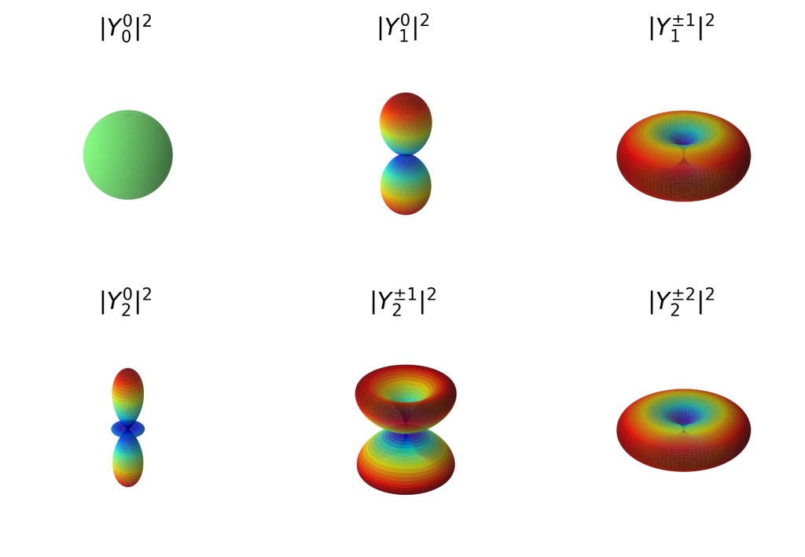

Figure 2: Absolute square of some spherical harmonics in 3D polar plot.

```python
import numpy as np
import matplotlib.pyplot as plt
from mpl_toolkits.mplot3d import Axes3D

def complex_spherical_harmonics_squared(l, m, theta, phi):
    """
    Calculates the absolute square of the normalized complex spherical harmonic Y_l^m(theta, phi).

    Args:
        l (int): The orbital quantum number.
        m (int): The magnetic quantum number.
        theta (numpy.ndarray): The polar angle (from 0 to pi).
        phi (numpy.ndarray): The azimuthal angle (from 0 to 2*pi).

    Returns:
        numpy.ndarray: The value of |Y_l^m(theta, phi)|^2.
    """
    if l == 0 and m == 0:
        return np.full_like(theta, 1.0 / (4.0 * np.pi))
    elif l == 1:
        if m == 0:
            return (3.0 / (4.0 * np.pi)) * np.cos(theta)**2
        elif abs(m) == 1:
            # The e^(i*phi) term squared has a magnitude of 1, so we only
            # need to square the sine term and the prefactor.
            return (3.0 / (8.0 * np.pi)) * np.sin(theta)**2
    elif l == 2:
        if m == 0:
            return (5.0 / (16.0 * np.pi)) * (3.0 * np.cos(theta)**2 - 1.0)**2
        elif abs(m) == 1:
            return (15.0 / (8.0 * np.pi)) * (np.sin(theta) * np.cos(theta))**2
        elif abs(m) == 2:
            return (15.0 / (32.0 * np.pi)) * np.sin(theta)**4
    else:
        # Return zeros for any other (l,m) pairs not explicitly handled.
        return np.zeros_like(theta)

# Set up the spherical coordinate grid
theta_phi_samples = 100
theta = np.linspace(0, np.pi, theta_phi_samples)
phi = np.linspace(0, 2 * np.pi, theta_phi_samples)
theta, phi = np.meshgrid(theta, phi)

# Define the (l, m) pairs to be plotted, avoiding redundant plots
# We only need to plot for m >= 0
lm_pairs = [
    (0, 0),
    (1, 0), (1, 1),
    (2, 0), (2, 1), (2, 2)
]

# Calculate the squared magnitude for all spherical harmonics and find the global maximum
all_R_values = []
for l, m in lm_pairs:
    R = complex_spherical_harmonics_squared(l, m, theta, phi)
    all_R_values.append(R)

# Find the global maximum to normalize all plots to the same scale
R_max = max(np.max(r) for r in all_R_values)

# Set up the plot with a grid of subplots (2 rows, 3 columns)
fig = plt.figure(figsize=(7, 4.67))

# Loop through the pairs and create a subplot for each
for i, (l, m) in enumerate(lm_pairs):
    ax = fig.add_subplot(2, 3, i + 1, projection='3d')
    # Set equal aspect ratio for the plot box
    ax.set_box_aspect([1, 1, 1])

    # Get the pre-calculated R and normalize it
    R = all_R_values[i] / np.max(all_R_values[i])#R_max
    if (l,m)==(0,0): R = R/1.5

    # Convert to Cartesian coordinates for plotting
    x = R * np.sin(theta) * np.cos(phi)
    y = R * np.sin(theta) * np.sin(phi)
    z = R * np.cos(theta)

    # Normalize the R values for color mapping and apply alpha
    norm = plt.Normalize(vmin=R.min(), vmax=R.max())
    if (l,m)==(0,0): norm = plt.Normalize(vmin=R.min()-.1, vmax=R.max()+.1)
    colors = plt.cm.jet(norm(R))

    # Plot the surface with colors based on the radius and alpha set directly
    ax.plot_surface(x, y, z, rstride=1, cstride=1, facecolors=colors,
                    edgecolor='none', alpha=0.8)

    # Plot the surface, with a solid, uniform color to better show shape
#    ax.plot_surface(x, y, z, rstride=1, cstride=1, cmap='viridis',
#                    edgecolor='none', alpha=0.8)


    # Manually set the axis limits to be identical across all plots
    ax.set_xlim([-1, 1])
    ax.set_ylim([-1, 1])
    ax.set_zlim([-1, 1])

    # Set titles for each subplot, using the pm symbol where appropriate
    if m == 0:
        title = r'$|Y_{' + str(l) + '}^0|^2$'
    else:
        title = r'$|Y_{' + str(l) + '}^{\pm ' + str(m) + '}|^2$'
    ax.set_title(title, fontsize=14)

    # Hide the axes to make the plot cleaner
    ax.set_axis_off()

plt.tight_layout()
plt.show()
```

# 7. Dirac notation

In **Dirac notation**, we can label the angular momentum eigenstates as $\lvert \ell, m \rangle$.

This reminds us that the spherical harmonics $Y_\ell^m(\theta,\varphi)$ are simply the coordinate-space representation of the abstract states $\lvert \ell, m \rangle$:

$$Y_\ell^m(\theta,\varphi) = \langle \theta, \varphi \,|\, \ell, m \rangle.$$

Hence, the two notations are fully consistent:  
- The **wavefunction view** uses functions on the sphere $Y_\ell^m(\theta,\varphi)$.  
- The **operator view** uses abstract eigenstates $\lvert \ell, m \rangle$.

**TipImportant**

The orthonormality relation then reads:

$$\langle \ell, m \,|\, \ell', m' \rangle = \delta_{\ell\ell'} \, \delta_{mm'}.$$

The eigenvalue equations are:

$$\boxed{\;
\hat{L}^2 \lvert \ell, m \rangle = \hbar^2 \ell(\ell+1) \lvert \ell, m \rangle, \qquad
\hat{L}_z \lvert \ell, m \rangle = \hbar m \lvert \ell, m \rangle
\;}$$

with the quantum numbers

$$\ell = 0, 1, 2, \dots, \qquad m = -\ell, -\ell+1, \dots, \ell-1, \ell.$$

# Appendix: Proof of the Ladder Operator Action

To justify the standard formulas for the action of the ladder operators on angular momentum eigenstates, let us derive them step by step.

## Step 1: Definitions and commutators

Define the ladder operators
$$\hat L_\pm = \hat L_x \pm i \hat L_y.$$

They satisfy the commutation relations
$$[\hat L_z, \hat L_\pm] = \pm \hbar \hat L_\pm,
\qquad
[\hat L_+, \hat L_-] = 2\hbar \hat L_z.$$

Thus, if $\hat L_z \lvert \ell,m \rangle = \hbar m \lvert \ell,m \rangle$, then
$$\hat L_z(\hat L_\pm \lvert \ell,m \rangle)
= (\hbar m \pm \hbar)\, \hat L_\pm \lvert \ell,m \rangle.$$

**NoteProof**

The commutator of $\hat L_z$ with the ladder operators is

$$[\hat L_z, \hat L_\pm]
= [\hat L_z, \hat L_x] \pm i [\hat L_z, \hat L_y]
= i \hbar \hat L_y \pm \hbar \hat L_x
= \pm \hbar (\hat L_x \pm i \hat L_y)
= \pm \hbar \hat L_\pm .$$

From this relation we obtain the operator identity

$$\hat L_z \hat L_\pm
= [\hat L_z, \hat L_\pm] + \hat L_\pm \hat L_z
= \pm \hbar \hat L_\pm + \hat L_\pm \hat L_z
= \hat L_\pm(\hat L_z \pm \hbar).$$

Thus, when acting on an eigenstate $\lvert \ell, m \rangle$ of $\hat L^2$ and $\hat L_z$, the operator $\hat L_\pm$ shifts the magnetic quantum number by one unit:

$$\hat L_z \, (\hat L_\pm \lvert \ell, m \rangle)
= (m \pm 1)\hbar \, (\hat L_\pm \lvert \ell, m \rangle).$$

This shows that $\hat L_\pm$ (if nonzero) produces another eigenstate with eigenvalue $m \pm 1$.
So we may write
$$\hat L_\pm \lvert \ell,m \rangle = C_\pm(\ell,m) \lvert \ell, m \pm 1 \rangle,$$
for some coefficient $C_\pm(\ell,m)$.

## Step 2: Determining $|C_\pm|^2$

Consider the squared norm:
$$\|\hat L_+ \lvert \ell,m \rangle \|^2
= \langle \ell,m | \hat L_- \hat L_+ | \ell,m \rangle.$$

Using the operator identity
$$\hat L_- \hat L_+ = \hat L^2 - \hat L_z^2 - \hbar \hat L_z,$$
and the eigenvalue equations
$$\hat L^2 \lvert \ell,m \rangle = \hbar^2 \ell(\ell+1) \lvert \ell,m \rangle,
\qquad
\hat L_z \lvert \ell,m \rangle = \hbar m \lvert \ell,m \rangle,$$
we get
$$\|\hat L_+ \lvert \ell,m \rangle \|^2
= \hbar^2 \big(\ell(\ell+1) - m(m+1)\big).$$

Thus,
$$|C_+(\ell,m)|^2 = \hbar^2 \big(\ell(\ell+1) - m(m+1)\big).$$

Similarly, using
$$\hat L_+ \hat L_- = \hat L^2 - \hat L_z^2 + \hbar \hat L_z,$$
we find
$$|C_-(\ell,m)|^2 = \hbar^2 \big(\ell(\ell+1) - m(m-1)\big).$$

## Step 3: Fixing the phase convention

We can choose the overall phase of the eigenstates such that $C_\pm$ are real and positive. With this standard convention we obtain:

$$\hat L_+ \lvert \ell,m \rangle
= \hbar \sqrt{\ell(\ell+1) - m(m+1)} \; \lvert \ell,m+1 \rangle,$$

$$\hat L_- \lvert \ell,m \rangle
= \hbar \sqrt{\ell(\ell+1) - m(m-1)} \; \lvert \ell,m-1 \rangle.$$

**Conclusion:**  
The ladder operators raise or lower the $m$ quantum number by one unit, with the above coefficients.